# Linear Analysis on Project Data

Emily Mendez

## Preparing the Data

From the previous data exploration of the Japanese Population Density, we found high traces of multicollinearity between variables. As most variables in the dataset have association with population or have population in their names of course we would be seeing high traces of association between the response and other variables. Therefore, as seen later in the report we will be removing perfect fit models as they are essentially the same as the population density and we want to explore a model that will involve the use of multiple variables to achieve a better fit model that is not as perfect.

```r
#Loading in the data and removing NAs
JapanPop=read.csv('/Users/admin/Documents/Csvv/japan.csv',header=TRUE)
attach(JapanPop)
JapanPop=JapanPop[,-13]
```

```r
#loading in libraries
library(olsrr)
```

## Creating the perfect model

As stated above, I wanted to demonstrate the similar variable along with the response which would be our perfect model. This will be shown in the forward selection of all variables in the dataset. Here we would expect the forward selection on the original dataframe to add only one variable since one of the variables exactly correlates to the population density. This variable would be TpopulationJuly; this indicates the total population as of July 1 and PopDensity indicates the population Density as of July 1.

```r
Testmodel=lm(PopDensity~.,data = JapanPop)
ols_step_forward_p(Testmodel)
```

```
##
##                                 Selection Summary
## ----------------------------------------------------------------------------------
##         Variable                          Adj.
## Step        Entered         R-Square    R-Square     C(p)        AIC         RMSE
## ----------------------------------------------------------------------------------
##    1    TPopulation1July      1.0000      1.0000    5.0316    -1312.9637    0.0000
## ----------------------------------------------------------------------------------
```

> Therefore, because we already found our perfect model and other variables are also almost perfect, we would want to explore a relationship where lowly correlated variables (with respect to the response) are able to be useful in predicting the response.

## Assessing Collinearity

Detection of collinearity could produce unreliable estimates and errors; therefore, In this section we will be assessing collinearity once again between our variables. Here we create a function to sum how many variables have a moderate to high correlation $x>0.65$ and subset the variables that have a lower one.

```r
#Checking correlations
corMat=round(cor(JapanPop),3)
temp1=length(colnames(JapanPop))
```

```r
#Creating function to get rid of variables with high correlation among each other
#In order to see high correlations we take the absolute value of them from the corrMatrix
temp=ifelse(abs(corMat)>0.65,1,0)
checkMC=function(x){
  var=sum(temp[x,])-1
  return(var)
}
#Subtracting 1 because of the correlation they have with themselves
```

```r
#Looking at which variables have the highest amount of correlation with other predictors
vec=seq(1:temp1)
NoCol=sapply(vec,checkMC)
CorrVar=cbind(colnames(temp),NoCol)
CorrVar
```

```
##                                NoCol
##  [1,] "Time"                   "51"
##  [2,] "TPopulation1Jan"        "47"
##  [3,] "TPopulation1July"       "47"
##  [4,] "TPopulationMale1July"   "44"
##  [5,] "TPopulationFemale1July" "48"
##  [6,] "PopDensity"             "47"
##  [7,] "PopSexRatio"            "20"
##  [8,] "MedianAgePop"           "50"
##  [9,] "NatChange"              "45"
## [10,] "NatChangeRT"            "50"
## [11,] "PopChange"              "42"
## [12,] "PopGrowthRate"          "49"
## [13,] "Births"                 "49"
## [14,] "Births1519"             "34"
```

[output cut: 40 more lines]

```r
#we will model the ones with 43 or below, just to have variables to pick from
```

> As expected many of our variables are highly correlated with each other; furthermore, we will have to remove these variables and test the others. We set our standard of separation as the mean of the number of variables associated. Notice that the amount of variables we have is 53 not including our response.

```r
#Which values are less than the mean
numericCol=as.numeric(CorrVar[,2])
temp2=which(numericCol< mean(numericCol))
temp2
```

```
##  [1]  7 11 14 18 19 20 21 22 23 36 39 43 53 54
```

> Now we find the predictors associated with the row numbers. Its possible to just look at the data given above but we can calculate it as well.

```r
findingColNames=function(temp2GoesHere){
  ColNam=CorrVar[temp2GoesHere,1]
  ColNum=CorrVar[temp2GoesHere,2]
  Cbin=cbind(ColNam,ColNum)
  return(Cbin)
}
findingColNames(temp2)
```

```
##       ColNam          ColNum
##  [1,] "PopSexRatio"   "20"
##  [2,] "PopChange"     "42"
##  [3,] "Births1519"    "34"
##  [4,] "MAC"           "24"
##  [5,] "SRB"           "1"
##  [6,] "Deaths"        "31"
##  [7,] "DeathsMale"    "37"
##  [8,] "DeathsFemale"  "28"
##  [9,] "CDR"           "7"
## [10,] "InfantDeaths"  "43"
## [11,] "Under5Deaths"  "42"
## [12,] "Q0040Female"   "43"
## [13,] "NetMigrations" "37"
## [14,] "CNMR"          "36"
```

> We will be considering 14 predictors

## Subsetting the Data and Assessing collinearity

```r
#subsetted data
JapPopD1 =JapanPop[,c(6,7,11,14,18,19,20,21,22,23,36,39,43,53,54)]
head(JapPopD1)
```

```
##   PopDensity PopSexRatio PopChange Births1519    MAC   SRB  Deaths DeathsMale
## 1   223.8526     96.0818  1393.571     54.936 29.663 105.9 933.809    479.249
## 2   227.3833     96.1742  1267.280     45.965 29.560 105.0 862.235    441.729
## 3   230.6694     96.2530  1209.299     38.038 29.411 105.1 788.162    404.473
## 4   233.6824     96.3191  1061.454     31.765 29.217 105.2 796.456    409.584
## 5   236.4314     96.3684  1010.303     27.901 29.037 106.0 742.817    388.751
## 6   239.0779     96.4096   984.222     25.617 28.858 105.8 714.063    374.027
##   DeathsFemale    CDR InfantDeaths Under5Deaths Q0040Female NetMigrations
## 1      454.560 11.078      138.960      224.485    195.9960       -61.846
## 2      420.506 10.065      118.686      200.424    171.9228       -44.626
## 3      383.689  9.068       97.792      157.963    145.1796       -37.471
## 4      386.872  9.046       89.853      140.429    134.8703       -39.697
## 5      354.065  8.337       78.798      119.606    124.4422       -51.485
## 6      340.037  7.923       69.042       99.260    109.8072       -72.784
##     CNMR
## 1 -0.734
## 2 -0.521
## 3 -0.431
## 4 -0.451
## 5 -0.578
## 6 -0.808
```

```r
#same method for assessing correlations among each other
corMat2=round(cor(JapPopD1),3)
temp3=ifelse(abs(corMat2)>0.65,1,0)

checkMC2=function(x){
  var=sum(temp3[x,])-1
  return(var)
}

var1=length(colnames(JapPopD1))
vec1=seq(1:var1)
num1=sapply(vec1,checkMC2)
CorrVar=cbind(colnames(temp3),num1)
CorrVar
```

```
##                       num1
##  [1,] "PopDensity"    "8"
##  [2,] "PopSexRatio"   "7"
##  [3,] "PopChange"     "7"
##  [4,] "Births1519"    "4"
##  [5,] "MAC"           "7"
##  [6,] "SRB"           "1"
##  [7,] "Deaths"        "8"
##  [8,] "DeathsMale"    "9"
##  [9,] "DeathsFemale"  "7"
## [10,] "CDR"           "6"
## [11,] "InfantDeaths"  "5"
## [12,] "Under5Deaths"  "4"
## [13,] "Q0040Female"   "5"
## [14,] "NetMigrations" "6"
## [15,] "CNMR"          "6"
```

> In this data set we have 15 variables, here we see that some predictors have a moderate to high correlation to other variables in this subset. Therefore, instead of subsetting to another dataframe we will begin to build a model with the variables that have a less number.

## Building models

#### Model 1

```r
#variables with a less than 7 from the data above.

lin.model=lm(PopDensity~Births1519+SRB+CDR+InfantDeaths+Under5Deaths+Q0040Female+NetMigrations+CNMR,data=JapPopD1)
summary(lin.model)
```

```
##
## Call:
## lm(formula = PopDensity ~ Births1519 + SRB + CDR + InfantDeaths +
##     Under5Deaths + Q0040Female + NetMigrations + CNMR, data = JapPopD1)
##
## Residuals:
##     Min      1Q  Median      3Q     Max
## -7.6245 -1.5557 -0.2939  1.6937  8.6308
##
## Coefficients:
##                 Estimate Std. Error t value Pr(>|t|)
## (Intercept)    362.63936  130.94269   2.769  0.00734 **
## Births1519       1.22917    0.14299   8.596 2.88e-12 ***
## SRB             -0.40061    1.23185  -0.325  0.74608
## CDR              0.78062    0.47681   1.637  0.10650
## InfantDeaths    -2.63054    0.27004  -9.741 2.93e-14 ***
## Under5Deaths     1.67587    0.11874  14.114  < 2e-16 ***
## Q0040Female     -1.11869    0.17583  -6.362 2.41e-08 ***
## NetMigrations    1.01416    0.08385  12.095  < 2e-16 ***
## CNMR          -122.81521    9.87930 -12.432  < 2e-16 ***
## ---
## Signif. codes:  0 '***' 0.001 '**' 0.01 '*' 0.05 '.' 0.1 ' ' 1
##
## Residual standard error: 3.022 on 64 degrees of freedom
## Multiple R-squared:  0.9942, Adjusted R-squared:  0.9935
## F-statistic:  1376 on 8 and 64 DF,  p-value: < 2.2e-16
```

> As shown above 2 variables are insignificant in this model, SRB and CDR. Although maybe if we remove some variables they may become significant to that specifc model. Although the $R^{2}$ in this model is at 0.99 meaning approximately 99% of the variablility in the mean population density can be explained by this linear model, there could be significant collinearity again and therefore rend that useless.

```r
ols_vif_tol(lin.model)
```

```
##       Variables   Tolerance        VIF
## 1    Births1519 0.109841135   9.104057
## 2           SRB 0.354980586   2.817055
## 3           CDR 0.170251694   5.873657
## 4  InfantDeaths 0.002030840 492.407088
## 5  Under5Deaths 0.004340211 230.403564
## 6   Q0040Female 0.002462426 406.103614
## 7 NetMigrations 0.003163466 316.109004
## 8          CNMR 0.003030265 330.004170
```

> The variance inflation factor for the 1st model remains significantly high for most of the predictor variables. As the VIF exceeds 10 and the tolerance is extremely close to zero, we consider this model not good and move on to fit another.

> It is possible to remove CNMR or Netmigrations as they correlate with one another. We can also choose 1 variable that relates to death to try and lower the VIF. Its also possible to use a variable that has a high correlation with the response variable in order to make a better fitting model along with our lower correlated variables in respect to the response.

#### Model 2

```r
#removing variables from model 1
#Removed Under5deaths and CNMR

lin.model2=lm(PopDensity~Births1519+SRB+CDR+InfantDeaths+NetMigrations,data=JapPopD1)
ols_vif_tol(lin.model2)
```

```
##       Variables Tolerance      VIF
## 1    Births1519 0.2285323 4.375748
## 2           SRB 0.4655660 2.147923
## 3           CDR 0.2418837 4.134218
## 4  InfantDeaths 0.1237738 8.079256
## 5 NetMigrations 0.2202907 4.539456
```

> The VIF has lowered below 10 and the tolerance seems to be a bit far from 0. Now we can move on to the summary.

```r
summary(lin.model2)
```

```
##
## Call:
## lm(formula = PopDensity ~ Births1519 + SRB + CDR + InfantDeaths +
##     NetMigrations, data = JapPopD1)
##
## Residuals:
##      Min       1Q   Median       3Q      Max
## -30.2806  -2.2444   0.8648   3.4671  16.0762
##
## Coefficients:
##                 Estimate Std. Error t value Pr(>|t|)
## (Intercept)   1330.85886  279.80722   4.756 1.09e-05 ***
## Births1519       2.56904    0.23928  10.736 3.33e-16 ***
## SRB            -10.14142    2.59636  -3.906 0.000221 ***
## CDR              5.09215    0.96557   5.274 1.54e-06 ***
## InfantDeaths    -1.80251    0.08349 -21.589  < 2e-16 ***
## NetMigrations   -0.06188    0.02425  -2.551 0.013017 *
## ---
## Signif. codes:  0 '***' 0.001 '**' 0.01 '*' 0.05 '.' 0.1 ' ' 1
##
## Residual standard error: 7.294 on 67 degrees of freedom
## Multiple R-squared:  0.9648, Adjusted R-squared:  0.9621
## F-statistic: 366.7 on 5 and 67 DF,  p-value: < 2.2e-16
```

> All pvalues are significant when the $\alpha=0.05$. We expect most of the observations in the model to lie within 14.588 (2S) units of the least square regression line.

> Questions to ask, is it possible to increase the $R^{2}$ and decrease the Residual standard error by adding a variable that has a moderately high correlation with the response.

#### Model 3

In the model below, we will be using the variable LEx, the life expectancy at Birth for both sexes. What correlation does this variable have with the population density?

```r
cor(LEx,PopDensity)
```

```
## [1] 0.9764049
```

> $r=0.9764$ which indicates that there is a strong positive correlation between them.

```r
# Adding LEx to the model
lin.model3=lm(PopDensity~LEx+Births1519+SRB+CDR+InfantDeaths+NetMigrations)
summary(lin.model3)
```

```
##
## Call:
## lm(formula = PopDensity ~ LEx + Births1519 + SRB + CDR + InfantDeaths +
##     NetMigrations)
##
## Residuals:
##     Min      1Q  Median      3Q     Max
## -6.7754 -1.8806  0.2617  1.6126 11.6867
##
## Coefficients:
##                 Estimate Std. Error t value Pr(>|t|)
## (Intercept)   -481.71134  177.76776  -2.710 0.008570 **
## LEx              9.29126    0.60822  15.276  < 2e-16 ***
## Births1519       0.34690    0.18432   1.882 0.064239 .
## SRB              1.06282    1.43062   0.743 0.460175
## CDR             -6.66905    0.89522  -7.450 2.56e-10 ***
## InfantDeaths     0.67219    0.16674   4.031 0.000146 ***
## NetMigrations   -0.02148    0.01177  -1.824 0.072612 .
## ---
## Signif. codes:  0 '***' 0.001 '**' 0.01 '*' 0.05 '.' 0.1 ' ' 1
##
## Residual standard error: 3.45 on 66 degrees of freedom
## Multiple R-squared:  0.9922, Adjusted R-squared:  0.9915
## F-statistic:  1404 on 6 and 66 DF,  p-value: < 2.2e-16
```

> In this model the pvalue of Births1519, SRB, and NetMigrations are insignificant.

```r
ols_vif_tol(lin.model3)
```

```
##       Variables   Tolerance        VIF
## 1           LEx 0.009900777 101.002178
## 2    Births1519 0.086197541  11.601259
## 3           SRB 0.343197476   2.913774
## 4           CDR 0.062979029  15.878301
## 5  InfantDeaths 0.006945688 143.974222
## 6 NetMigrations 0.209178677   4.780602
```

> The VIF value is extremely high to reduce it we will remove SRB because of its insignificance.

#### Model 4

```r
# removing SRB
lin.model4=lm(PopDensity~LEx+Births1519+CDR+NetMigrations,data=JapanPop)
summary(lin.model4)
```

```
##
## Call:
## lm(formula = PopDensity ~ LEx + Births1519 + CDR + NetMigrations,
##     data = JapanPop)
##
## Residuals:
##      Min       1Q   Median       3Q      Max
## -11.6518  -1.7537   0.1936   2.0634   9.3620
##
## Coefficients:
##                 Estimate Std. Error t value Pr(>|t|)
## (Intercept)   -2.188e+02  1.121e+01 -19.523  < 2e-16 ***
## LEx            6.985e+00  1.354e-01  51.603  < 2e-16 ***
## Births1519     1.022e+00  9.239e-02  11.066  < 2e-16 ***
## CDR           -3.123e+00  2.944e-01 -10.609 4.62e-16 ***
## NetMigrations -4.642e-02  9.709e-03  -4.781 9.72e-06 ***
## ---
## Signif. codes:  0 '***' 0.001 '**' 0.01 '*' 0.05 '.' 0.1 ' ' 1
##
## Residual standard error: 3.818 on 68 degrees of freedom
## Multiple R-squared:  0.9902, Adjusted R-squared:  0.9896
## F-statistic:  1717 on 4 and 68 DF,  p-value: < 2.2e-16
```

```r
ols_vif_tol(lin.model4)
```

```
##       Variables Tolerance      VIF
## 1           LEx 0.2447110 4.086453
## 2    Births1519 0.4200148 2.380868
## 3           CDR 0.7128831 1.402755
## 4 NetMigrations 0.3766477 2.655001
```

> Our VIF is low and tolerance is above 0.0. There is officially little collinearity in our model.

## Diagnositcs

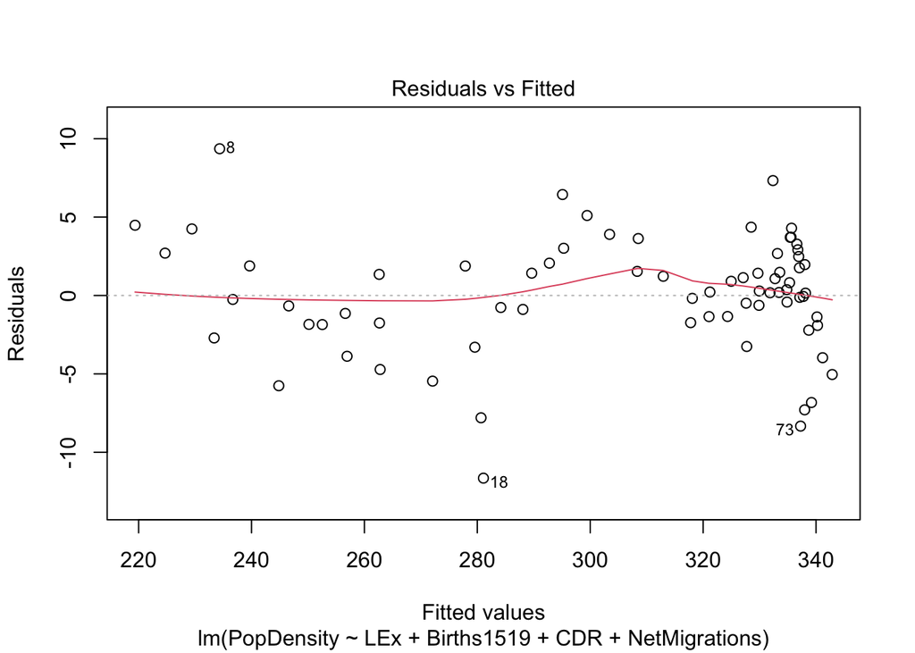

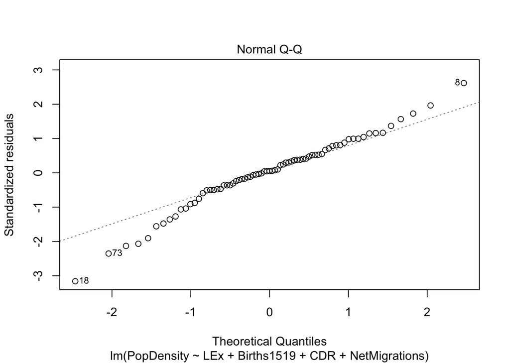

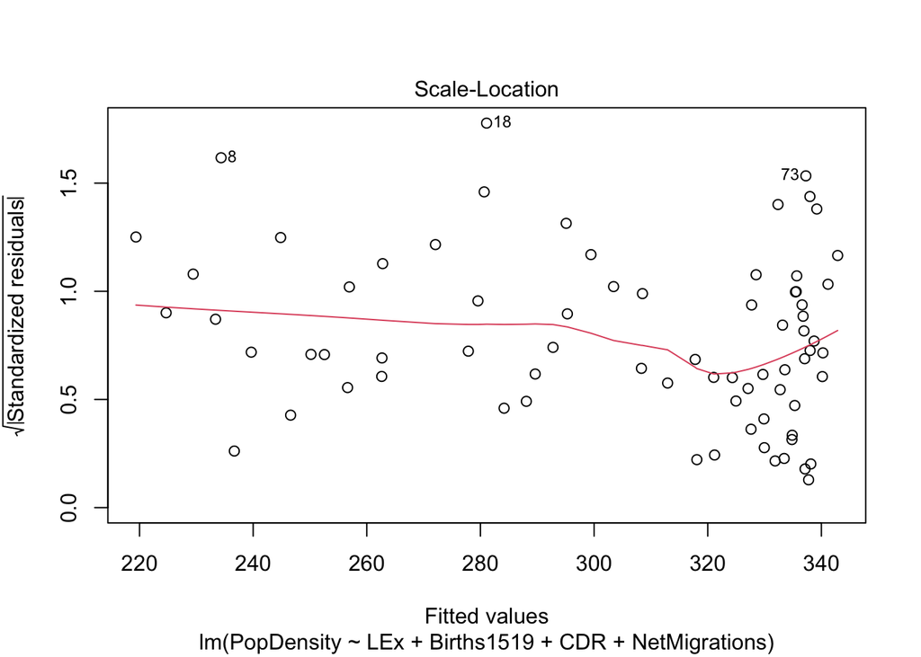

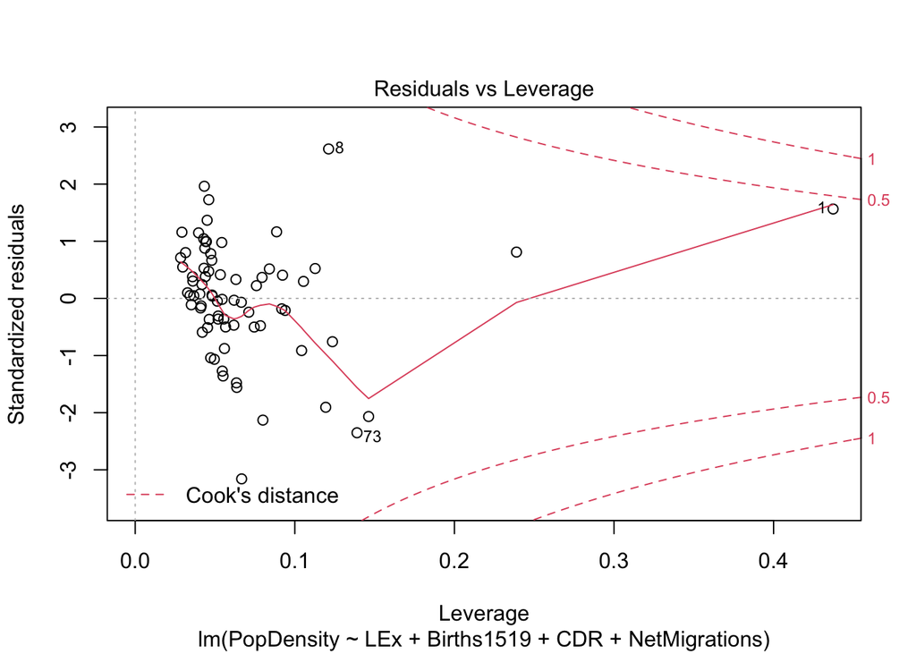

```r
plot(lin.model4)
```